# SportsCast_EDA_FeatureSelection

This notebook provides an EDA informing feature selection for the SportsCast modelling.

### Default setup

```python
from google.colab import drive
drive.mount('/content/drive', force_remount=False)
```

```python
%pdb on
```

```
Automatic pdb calling has been turned ON
```

```python
!pip install pmdarima
!pip install gluonts
!pip install mxnet
```

```python
import pandas as pd
import seaborn as sns
import matplotlib.pyplot as plt
import numpy as np
import time
```

```python
import matplotlib.pyplot as plt
import pmdarima as pm
import copy
from IPython.display import Image
from scipy.ndimage.interpolation import shift
from datetime import datetime, timedelta
```

```python
from pandas.io.json import json_normalize
import pickle
```

```python
!cp "/content/drive/My Drive/Project/feature_and_label_compilation.py" .
!cp "/content/drive/My Drive/Project/glnts.py" .
```

```python
import feature_and_label_compilation as ar
```

```python
PATH = '/content/drive/My Drive/Project'
```

```python
DATA_PATH = PATH+"/Data/Inputs/allFeats_dfs.p"
```

```python
def load_csv(path='../../data/input/full_dataset_4_seasons.csv'):
    data = pd.read_csv(path)
    return data
```

### Load feature data

Load pre-ingested feature data from file.

```python
try:
	f = open(DATA_PATH,"rb")
	all_features_raw = pickle.load(f)
except NameError:
	print('Couldn\'t open')
```

```
Exception ignored in: <_io.FileIO name='/content/drive/My Drive/Project/Data/Inputs/allFeats_dfs.p' mode='rb' closefd=True>
ResourceWarning: unclosed file <_io.BufferedReader name='/content/drive/My Drive/Project/Data/Inputs/allFeats_dfs.p'>
```

### EDA

This EDA is divided into 3 parts:

1. Analysis of most important features
2. Analysis of secondary features
3. Attempt to identify flucuations that should be present and explainable

#### Analyze base features

```python
player_num = 0
OWN_TEAM_IDX = 0
OPPONENT_TEAM_IDX = 1
DAYS_SINCE_LAST_GAME_IDX = 2
```

```python
def dfDiffFillNaNStart(df):
    #input: df
    return df.diff(periods=1).fillna(0) #Missing values at start, so fill 0
```

Load the base features

```python
opponent_team_df = pd.DataFrame({'opponent_team_id':all_features_raw['features_trn'][player_num][:,OPPONENT_TEAM_IDX]})
days_since_last_game_df = pd.DataFrame({'days_since_last_id':all_features_raw['features_trn'][player_num][:,DAYS_SINCE_LAST_GAME_IDX]})
player_pts_df = dfDiffFillNaNStart(all_features_raw['train_targets_unscaled'][player_num])
```

Preprocess the 'Days-Since' feature for better interpretability

```python
days_since_last_game_df[days_since_last_game_df['days_since_last_id']>0.5]=0 #DROP the off-season gap of 6 months
#Rescale to 82-games/regular season
days_since_df_resolution = np.nanmin(days_since_last_game_df[days_since_last_game_df>0])
days_since_last_game_df = round(1/days_since_df_resolution* days_since_last_game_df[days_since_last_game_df['days_since_last_id']<1])
```

```python
player_pts_df = abs(player_pts_df)
```

Get the first differences of the covariate time series as well

```python
#Get first diffs of each for 2-sides sequences, to properly test correlation
diff_player_pts = dfDiffFillNaNStart(player_pts_df).values
diff_opponent_team = dfDiffFillNaNStart(opponent_team_df).values
diff_days_since_last_game = dfDiffFillNaNStart(days_since_last_game_df).values
```

Visualize and compare the raw values

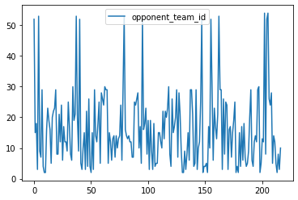

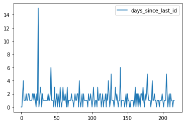

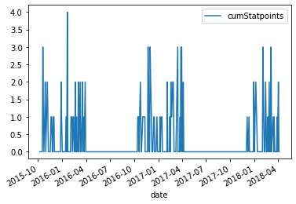

```python
opponent_team_df.plot()
days_since_last_game_df.plot()
player_pts_df.plot()
```

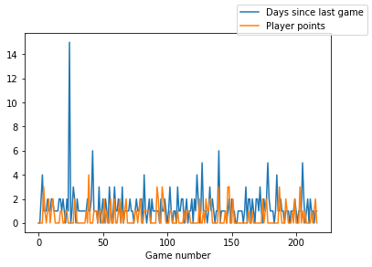

```python
plt.plot(days_since_last_game_df.values)
plt.plot(abs(player_pts_df).values)
plt.xlabel('Game number')
plt.figlegend(('Days since last game','Player points'))
```

```python
from statsmodels.graphics.tsaplots import acf

print(acf(player_pts_df))
print(acf(opponent_team_df))
print(acf(days_since_last_game_df))
```

[output not shown]

We see there may be correlation for the 'Days-Since' feature. Test using Pearson

```python
def getCrossCorr(y1,y2):
    npts = len(y1)
    ccov = np.correlate(y1 - y1.mean(), y2 - y2.mean(), mode='full')
    ccor = ccov / (npts * y1.std() * y2.std())

    '''
    lags = np.arange(-npts + 1, npts)
    plt.plot(lags, ccor)
    plt.axes().set_ylim(-1.1, 1.1)
    plt.axes().set_ylabel('cross-correlation')
    plt.axes().set_xlabel('lag of y1 relative to y2')
    '''

    return ccor
```

```python
def normalize_arr(arr):
  stdev = 1 if np.std(arr)==0 else np.std(arr)
  return (arr - np.mean(arr))/(stdev*np.sqrt(len(arr)))
```

```python
ccor = getCrossCorr(normalize_arr(player_pts_df.values).reshape(-1),normalize_arr(days_since_last_game_df.values).reshape(-1))
```

```python
print(f'The maximum cross-correlation between "Days-Since" and "Points" for player {player_num} is {max(abs(ccor))}')
```

[output not shown]

Test for the other players to see if any higher

```python
maxCorr = []

for player_num in range(len(all_features_raw['features_trn'])):
    #Raw values
    opponent_df = pd.DataFrame({'opponent_team_id':all_features_raw['features_trn'][player_num][:,OPPONENT_TEAM_IDX]})
    days_since_df = pd.DataFrame({'days_since_last_id':all_features_raw['features_trn'][player_num][:,DAYS_SINCE_LAST_GAME_IDX]})
    fixed = copy.deepcopy(all_features_raw['train_targets_unscaled'][player_num])
    pts_df = dfDiffFillNaNStart(fixed)

    #Preprocess 'Days-since'
    days_since_df[days_since_df['days_since_last_id']>0.5]=0 #DROP the off-season gap of 6 months
    days_since_df_resolution = np.nanmin(days_since_df[days_since_df>0])
    days_since_df = round(1/days_since_df_resolution* days_since_df[days_since_df['days_since_last_id']<1])

    #Get first diffs of each for 2-sides sequences, to properly test correlation
    diff_player_pts = dfDiffFillNaNStart(pts_df).values
    diff_opponent_team = dfDiffFillNaNStart(opponent_df).values
    diff_days_since_last_game = dfDiffFillNaNStart(days_since_df).values

    crossCorr = getCrossCorr(normalize_arr(diff_player_pts).reshape(-1),normalize_arr(diff_days_since_last_game).reshape(-1))
    maxCorr.append(max(abs(crossCorr)))
```

```python
print(f'The mean correlation between days-since and points amongst all players is: {np.mean(maxCorr)}')
```

```
The mean correlation between days-since and points amongst all players is: 0.3132258265273127
```

Hence a weak correlation.

We plot points against gap in two ways to determine the sign of the correlation.

1) a 2D coloured histogram

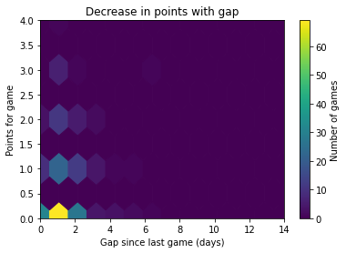

```python
fig = plt.figure()
ax = plt.axes()
hb = plt.hexbin(abs(days_since_last_game_df).values,abs(player_pts_df).values,gridsize=(14,4))
ax.axis([0, 14, 0, 4])

ax.set_title("Decrease in points with gap")
plt.xlabel('Gap since last game (days)')
plt.ylabel('Points for game')

cb = fig.colorbar(hb, ax=ax)
cb.set_label('Number of games')
```

2) a 3D hisotgram

```python
hist, xedges, yedges = np.histogram2d(abs(days_since_last_game_df).values.reshape(-1), abs(player_pts_df).values.reshape(-1), \
                                      bins=[15,5], \
                                      range=[[0, 14], [0, 4]])
```

```python
xpos, ypos = np.meshgrid(xedges[:-1] + 0.25, yedges[:-1] + 0.25, indexing="ij")
xpos = xpos.ravel()
ypos = ypos.ravel()
zpos = 0
```

```python
dx = dy = 0.5 * np.ones_like(zpos)
dz = hist.ravel()
```

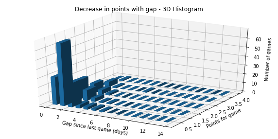

```python
fig = plt.figure(figsize=(10,5))
ax = fig.add_subplot(111, projection='3d')
ax.bar3d(xpos, ypos, zpos, dx, dy, dz, zsort='average')
plt.xlabel('Gap since last game (days)')
plt.ylabel('Points for game')
ax.set_zlabel('Number of games')
ax.set_title("Decrease in points with gap - 3D Histogram")
```

Hence, we see a weak negative relationship, as expected.

#### Analyze other features in dataset

We then collect the other features in the dataset to analyze.

```python
player_num = 0

#Indices of columns for 'extra' features
extra_features_dict = \
{
    'isHome': 0,
    'isOT': 1,
    'isWin': 2,
    'statAssists': 3,
    'statBlocked': 4,
    'statFaceoffpct': 5,
    'statGoals': 6,
    'statHits': 7,
    'statPenaltyminutes': 8,
    'statPlusminus': 9,
    'statShifts': 10,
    'statShotpct': 11,
    'statShots': 12,
    'statTimeonice': 13
}
```

```python
extra_features_allPlayers = {}
for player_num in range(len(all_features_raw)):
    extra_features_player = pd.DataFrame(all_features_raw['extra_features_trn'][player_num])
    extra_features_player.columns = extra_features_dict.keys()
    extra_features_player = extra_features_player.fillna(0)
    extra_features_player.replace(True,int(1),inplace=True)
    stat_time_seconds = []
    for str_time in extra_features_player['statTimeonice']:
        time = datetime.strptime(str_time,"%M:%S")
        seconds = timedelta(minutes=time.minute, seconds=time.second).total_seconds()
        stat_time_seconds.append(seconds)
    extra_features_player['statTimeonice'] = stat_time_seconds
    extra_features_allPlayers[all_features_raw.index[player_num]] = extra_features_player
```

First, visualize relationships between these features and the points for a given player.

```python
extra_features_player = extra_features_allPlayers[all_features_raw.index[player_num]]
```

```python
#Get first diffs of each for 2-sides sequences
diff_isHome = dfDiffFillNaNStart(extra_features_player['isHome']).values
diff_isOT = dfDiffFillNaNStart(extra_features_player['isOT']).values
diff_isWin = dfDiffFillNaNStart(extra_features_player['isWin']).values
diff_timeOnIce = dfDiffFillNaNStart(extra_features_player['statTimeonice']).values
```

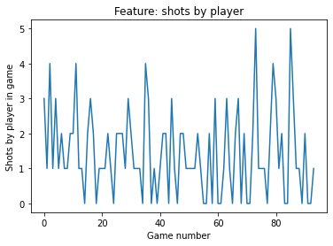

```python
extra_features_player['statShots'].plot()
plt.xlabel('Game number')
plt.ylabel('Shots by player in game')
plt.title('Feature: shots by player')
```

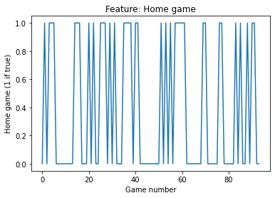

```python
extra_features_player['isHome'].plot()
plt.xlabel('Game number')
plt.ylabel('Home game (1 if true)')
plt.title('Feature: Home game')
```

We now determine the maximum cross-correlation between any given feature and # of points for all players.

```python
def getCrossCorrsAllPlayers_Diff(targets_all_players,features_all_players,players_list,feature_name:str):
    maxCorr = []

    for player_num in range(len(players_list)):
        #Raw values
        fixed = copy.deepcopy(targets_all_players[player_num])

        #Preprocess targets
        fixed = abs(fixed)
        player_pts_df = dfDiffFillNaNStart(fixed)

        #Get first diffs of each for 2-sides sequences, to properly test correlation
        diff_player_pts = dfDiffFillNaNStart(player_pts_df).values
        diff_feature = dfDiffFillNaNStart(features_all_players[players_list[player_num]][feature_name]).values

        crossCorr = getCrossCorr(diff_player_pts.reshape(-1),diff_feature.reshape(-1))
        maxCorr.append(max(abs(crossCorr)))

    return maxCorr
```

First, test with feature 'time on ice'.

```python
statTimeonice_crossCorrs = getCrossCorrsAllPlayers_Diff(targets_all_players = all_features_raw['train_targets_unscaled'], players_list = all_features_raw.index, features_all_players = extra_features_allPlayers, feature_name = 'statTimeonice')
mean_statTimeonice_crossCorrs = np.mean(statTimeonice_crossCorrs)
mean_statTimeonice_crossCorrs
```

```
0.24596232781988503
```

Then, look for top 4 features most cross-correlated with # of points for player.

```python
crossCorrs = getCrossCorrsAllPlayers_Diff(targets_all_players = all_features_raw['train_targets_unscaled'], players_list = all_features_raw.index, features_all_players = extra_features_allPlayers, feature_name = 'statAssists')
mean = np.mean(crossCorrs)
mean
```

```
0.7089041222442247
```

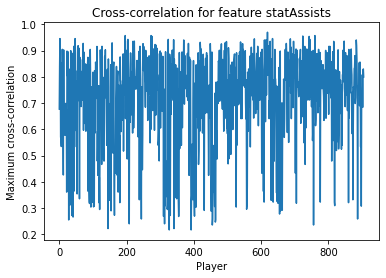

```python
plt.plot(crossCorrs)
plt.xlabel('Player')
plt.ylabel('Maximum cross-correlation')
plt.title('Cross-correlation for feature statAssists')
```

```python
crossCorrs = getCrossCorrsAllPlayers_Diff(targets_all_players = all_features_raw['train_targets_unscaled'], players_list = all_features_raw.index, features_all_players = extra_features_allPlayers, feature_name = 'statGoals')
mean = np.mean(crossCorrs)
mean
```

```
0.5414966409970791
```

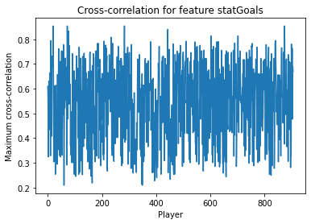

```python
plt.plot(crossCorrs)
plt.xlabel('Player')
plt.ylabel('Maximum cross-correlation')
plt.title('Cross-correlation for feature statGoals')
```

```python
crossCorrs = getCrossCorrsAllPlayers_Diff(targets_all_players = all_features_raw['train_targets_unscaled'], players_list = all_features_raw.index, features_all_players = extra_features_allPlayers, feature_name = 'statPlusminus')
mean = np.mean(crossCorrs)
mean
```

```
0.43003336326620295
```

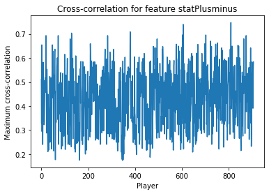

```python
plt.plot(crossCorrs)
plt.xlabel('Player')
plt.ylabel('Maximum cross-correlation')
plt.title('Cross-correlation for feature statPlusminus')
```

```python
crossCorrs = getCrossCorrsAllPlayers_Diff(targets_all_players = all_features_raw['train_targets_unscaled'], players_list = all_features_raw.index, features_all_players = extra_features_allPlayers, feature_name = 'statShotpct')
mean = np.mean(crossCorrs)
mean
```

```
0.48199068629653957
```

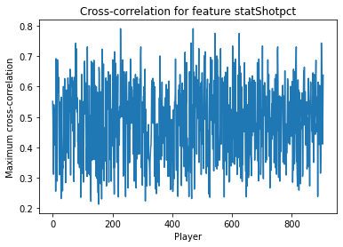

```python
plt.plot(crossCorrs)
plt.xlabel('Player')
plt.ylabel('Maximum cross-correlation')
plt.title('Cross-correlation for feature statShotpct')
```

From this we see that the most correlated features are:

1. Number of Assists
2. Number of Goals
3. Shot percentage
4. Plus/minus

#### Analyze explained fluctuations

In this section, we attempt to correlate fluctations in the # of points gained by player (target) to "PRIMARY" features.

"Primary" feature: one which can be known beforehand (e.g. team number, home-away game). Changes in these are meaningful, e.g. change in team-number implies player trade.

##### Team change

```python
player_num = 0
OWN_TEAM_IDX = 0
```

```python
all_features_raw['features_trn'][2][:,OWN_TEAM_IDX]
```

```
array([1., 1., 1., 1., 1., 1., 1., 1., 1., 1., 1., 1., 1., 1., 1., 1., 1.,
       1., 1., 1., 1., 1., 1., 1., 1., 1., 1., 1., 1., 1., 1., 1., 1., 1.,
       1., 1., 1., 1., 1., 1., 1., 1., 1., 1., 1., 1., 1., 1., 1., 1., 1.,
       1., 1., 1., 1., 1., 1., 1., 1., 1., 1., 1., 1., 1., 1., 1., 1., 1.,
       1., 1., 1., 1., 1., 1., 1., 1., 1., 1., 1., 1., 1., 1., 2., 2., 2.,
       2., 2., 2., 2., 2., 2., 2., 2., 2., 2., 2., 2., 2., 2., 2., 2., 2.,
       2., 2., 2., 2., 2., 2.])
```

```python
maxCorr = []
players_list = all_features_raw.index

for player_num in range(len(players_list)):
    #Raw values
    own_team_df = pd.DataFrame({'own_team_id':all_features_raw['features_trn'][player_num][:,OWN_TEAM_IDX]})
    fixed = copy.deepcopy(all_features_raw['train_targets_unscaled'][player_num])

    #Preprocess targets
    fixed = abs(fixed)
    player_pts_df = dfDiffFillNaNStart(fixed)

    #Get first diffs of each for 2-sides sequences, to properly test correlation
    diff_player_pts_arr = dfDiffFillNaNStart(player_pts_df).values
    diff_feature_arr = dfDiffFillNaNStart(own_team_df).values

    try:
      if not all(diff_feature_arr == diff_feature_arr[0]): #ONLY TRY TO CROSS-CORRELATE IF TEAM CHANGE
        crossCorr = getCrossCorr(diff_player_pts_arr.reshape(-1), \
                                  diff_feature_arr.reshape(-1) \
                                )
        maxCorr.append(max(abs(crossCorr)))
      else:
        #If no team change, ignore
        crossCorr = -1
        maxCorr.append(np.nan)
    except Warning as werr:
      print(werr)
      break
```

```python
np.nanmean(maxCorr)
```

```
0.32212769989680606
```

Look for player most affected by team change.

```python
#Player most affected by team change
team_chg_player = np.nanargmax(maxCorr)
```

```python
all_features_raw.index[team_chg_player]
```

```
'Keith Yandle'
```

```python
own_team_df = pd.DataFrame({'own_team_id':all_features_raw['features_trn'][team_chg_player][:,OWN_TEAM_IDX]})
fixed = copy.deepcopy(all_features_raw['train_targets_unscaled'][team_chg_player])
fixed = abs(fixed[:-1])
player_pts_df = dfDiffFillNaNStart(fixed)

#Get first diffs of each for 2-sides sequences, to properly test correlation
diff_player_pts = dfDiffFillNaNStart(player_pts_df).values
diff_own_team = dfDiffFillNaNStart(own_team_df).values
```

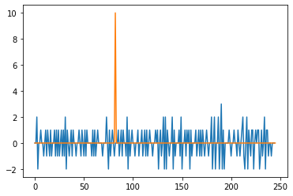

```python
plt.plot(diff_player_pts)
plt.plot(diff_own_team)
```

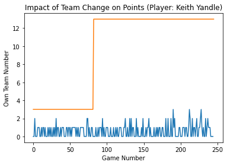

```python
plt.plot(player_pts_df.values)
plt.plot(own_team_df.values)
plt.xlabel('Game Number')
plt.ylabel('Own Team Number')
plt.title('Impact of Team Change on Points (Player: Keith Yandle)')
```

This shows it is unclear whether player is really impacted by team change (since impact on points is delayed).

Check results for JT Miller (c.f. https://www.rawcharge.com/2018/9/28/17910952/tampa-bay-lightning-nikita-kucherov-2018-2019-season-preview-top-six-forwards-stamkos-brayden-point )

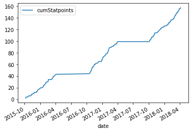

```python
JT_Miller_results = all_features_raw[all_features_raw.index=='J.T. Miller']
JT_Miller_results.iloc[0,1].plot()
```

```python
JT_Miller_results
```

|  | player_train_df | train_targets_unscaled | test_targets_unscaled | features_trn | features_test | extra_features_trn | extra_features_test | forecastStart |
| --- | --- | --- | --- | --- | --- | --- | --- | --- |
| J.T. Miller | date cumStatpoints 22939 2015-10-... | cumStatpoints date ... | cumStatpoints date ... | [[3.0, 16.0, 1.0], [3.0, 29.0, 0.0053763440860... | [[14.0, 13.0, 1.0], [14.0, 23.0, 0.02150537634... | [[False, False, True, 2, 0, nan, 0, 3, 0, 2, 1... | [[True, False, True, 0, 0, 71.43, 0, 3, 4, 0, ... | 2018-10-03 |
| J.T. Miller | date cumStatpoints 22939 2015-10-... | cumStatpoints date ... | cumStatpoints date ... | [[3.0, 16.0, 1.0], [3.0, 29.0, 0.0053763440860... | [[14.0, 13.0, 1.0], [14.0, 23.0, 0.02150537634... | [[False, False, True, 2, 0, nan, 0, 3, 0, 2, 1... | [[True, False, True, 0, 0, 71.43, 0, 3, 4, 0, ... | 2018-10-03 |

```python
JT_Miller_features_trn = JT_Miller_results.iloc[0,3]
JT_Miller_targets_trn = JT_Miller_results.iloc[0,1]
```

```python
JT_Miller_targets_trn
```

| date | cumStatpoints |
| --- | --- |
| 2015-10-07 | 2 |
| 2015-10-09 | 3 |
| 2015-10-10 | 4 |
| 2015-10-13 | 4 |
| 2015-10-15 | 4 |
| ... | ... |
| 2018-03-30 | 155 |
| 2018-04-01 | 155 |
| 2018-04-03 | 156 |
| 2018-04-06 | 156 |
| 2018-04-07 | 157 |

246 rows × 1 columns

```python
JT_own_team_df = pd.DataFrame({'own_team_id':JT_Miller_features_trn[:,0]})
JT_fixed = copy.deepcopy(JT_Miller_targets_trn)
JT_player_pts_df = dfDiffFillNaNStart(JT_fixed)

#Get first diffs of each for 2-sides sequences, to properly test correlation
JT_diff_player_pts = dfDiffFillNaNStart(JT_player_pts_df).values
JT_diff_own_team = dfDiffFillNaNStart(JT_own_team_df).values
```

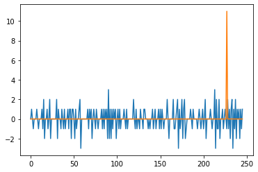

```python
plt.plot(JT_diff_player_pts)
plt.plot(JT_diff_own_team)
```

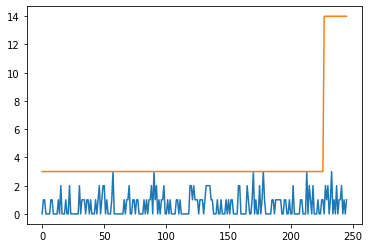

```python
plt.plot(JT_player_pts_df.values)
plt.plot(JT_own_team_df.values)
```

No apparent affect of team change for JT Miller.

##### Cross Correlation Between Teammates, Opponents

We would expect a positive correlation between teammates, and a negative correlation between opponents. We attempt to identify this.

###### Teammates

We first try to find a correlation between two players, since the data is less sparse than opponents.

```python
dict_player_ind = dict( zip( all_features_raw.index,range(len(all_features_raw.index)) ) )
```

```python
#Select two teammates
player1_num = dict_player_ind['Steven Stamkos']
player2_num = dict_player_ind['Nikita Kucherov']
```

```python
#Get raw values
player1_df = copy.deepcopy(all_features_raw['train_targets_unscaled'][player1_num])
player2_df = copy.deepcopy(all_features_raw['train_targets_unscaled'][player2_num])

#Preprocess targets
player1_df = abs(player1_df)
player2_df = abs(player2_df)
```

```python
#Get intersection of dates (i.e. common games)
first_df = copy.deepcopy(player1_df)
other_df = copy.deepcopy(player2_df)
common_df = pd.merge(first_df,other_df,left_index=True, right_index=True)
common1_df = common_df['cumStatpoints_x']
common2_df = common_df['cumStatpoints_y']
```

```python
max_corr = []
#Find correlation
#Get first diffs of each for 2-sides sequences, to properly test correlation
player1_pts = dfDiffFillNaNStart(common1_df).values
player2_pts = dfDiffFillNaNStart(common2_df).values

player2_pts[player2_pts>50] = 0

#Get correlation
crossCorr = getCrossCorr(player1_pts.reshape(-1), \
                        player2_pts.reshape(-1) \
                        )
max_corr = max(abs(crossCorr))
```

```python
max_corr
```

```
0.4388425375115702
```

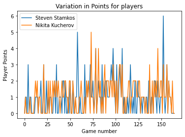

```python
plt.plot(player1_pts)
plt.plot(player2_pts)
plt.xlabel('Game number')
plt.ylabel('Player Points')
plt.title('Variation in Points for players')
plt.legend(('Steven Stamkos','Nikita Kucherov'))
```

This shows a relatively high correlation between teammates.

###### Opponents

We then compare between two opponents. Since opponent data is sparse, we compare a player who was an opponent and then became a teammate.

Get common data based on one-hot data for a player 1.

```python
FULL_DATA_PATH = PATH+"/Data/Inputs/full_dataset_4_seasons.csv"
data = pd.read_csv(FULL_DATA_PATH)
data['date'] = pd.to_datetime(data['date'])
```

```python
ROSTER_PATH = PATH+"/Data/Inputs/full_roster_4_seasons.csv"
full_roster = pd.read_csv(ROSTER_PATH)
```

```python
import pdb

#Creates ternary one-hot encodings
def addPlayerFeatures(data_df=None, player_name=None, roster=None):
    '''
    Input
    ----
    data_df: full game-level data for ALL players
    player_name: name of the player for which augmented features are being construcuted
    roster: ALL players in the league, with associated Position

    Return
    ----
    Data w/ columns for features of other players.
    NOTE: these columns currently INCLUDE a feature for presence of the player 'player_name' (for simplicity)
    #TODO: add/remove others, depending on HOW MANY FEATURES ARE KNOWN AT SELECTION TIME

    '''
    #pdb.set_trace()

    if (data_df is None) or (player_name is None) or (roster is None):
        return None

    player_df = data_df[data_df['name']==player_name]
    playerFeat_df = pd.DataFrame(columns=['date']+list(roster['name'].values))
    game_idx = 0
    for _,row in player_df.iterrows():
        game_date = row['date']
        game_date = game_date.strftime('%Y-%m-%d')

        team_name = row['teamName'] # mostly unchanging for player between games (rows)
        opponent_name = row['opponentName']
        all_players_date = data_df[data_df['gameLink'] == row['gameLink']][['name','teamName']].drop_duplicates() #All players for that game
        players_on_team = all_players_date[all_players_date['teamName']==team_name]['name']
        players_on_opposition = all_players_date[all_players_date['teamName']==opponent_name]['name']
        ternary_oneHot_feat = [1 if (player in players_on_team.values) else -1 if (player in players_on_opposition.values) else 0 for player in roster['name']]

        playerFeat_df.loc[game_idx,:] = [game_date] + ternary_oneHot_feat
        game_idx = game_idx + 1
        '''
        for player in roster['name']:
            #playerFeat_df.loc[row,player] = 1 if ((player in players_on_team) or (player in players_on_opposition)) else 0 #Decomposes into players on team OR opposition
            if ((player in players_on_team) or (player in players_on_opposition)):
              playerFeat_df.loc[idx,player] = 1  if (player in players_on_team) else -1
            else:
              playerFeat_df.loc[idx,player] = 0
        '''

    newFeatures_df = playerFeat_df
    return newFeatures_df
```

```python
oneHot_player1 = addPlayerFeatures(data,'Steven Stamkos', full_roster)
```

```python
oneHot_player1 = oneHot_player1[oneHot_player1['date']<'2018-04-02']
```

```python
common_games_df = oneHot_player1['J.T. Miller'].iloc[:,0]
```

```python
opponent_game_idxs = common_games_df[common_games_df==-1].index #Games when opponents
teammates_game_idxs = common_games_df[common_games_df==1].index #Games when teammates
```

```python
together_game_idxs = opponent_game_idxs.union(teammates_game_idxs) #All common games
```

```python
#Select two teammates
player1_num = dict_player_ind['Steven Stamkos']
player3_num = dict_player_ind['J.T. Miller']
```

```python
#Get raw values
player1_df = copy.deepcopy(all_features_raw['train_targets_unscaled'][player1_num])
player3_df = copy.deepcopy(all_features_raw['train_targets_unscaled'][player3_num])

#Preprocess targets
player1_df = abs(player1_df)
player3_df = abs(player3_df)
player1_pts_df = dfDiffFillNaNStart(player1_df)
player3_pts_df = dfDiffFillNaNStart(player3_df)
diff_player1_pts_df = dfDiffFillNaNStart(player1_pts_df)
diff_player3_pts_df = dfDiffFillNaNStart(player3_pts_df)
```

```python
#Get games when player together for first player
first_df = copy.deepcopy(diff_player1_pts_df)
second_df = copy.deepcopy(diff_player3_pts_df)
common1_df = first_df.iloc[together_game_idxs]
```

```python
#Get intersection of dates (i.e. common games for third player)
common_df = pd.merge(common1_df,second_df,left_index=True, right_index=True) #Contains change in points for common games
common2_df = common_df['cumStatpoints_y']
```

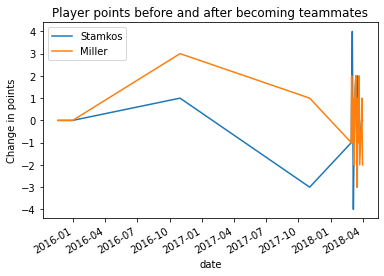

```python
common_df.plot()
plt.legend(('Stamkos','Miller'))
plt.ylabel('Change in points')
plt.title('Player points before and after becoming teammates')
```

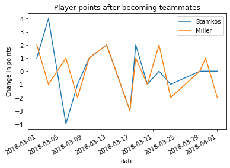

```python
common_df[common_df.index>'2018-02-28'].plot()
plt.legend(('Stamkos','Miller'))
plt.ylabel('Change in points')
plt.title('Player points after becoming teammates')
```

```python
#Find correlation
#Get first diffs of each for 2-sides sequences, to properly test correlation
diff_pts_player1 = common1_df.values
diff_pts_player3 = common2_df.values


#Get correlation before becoming teammates
crossCorr_before = getCrossCorr(diff_pts_player1[:4].reshape(-1), \
                        diff_pts_player3[:4].reshape(-1) \
                        )

#Get correlation before becoming teammates
crossCorr_after = getCrossCorr(diff_pts_player1[4:].reshape(-1), \
                        diff_pts_player3[4:].reshape(-1) \
                        )
```

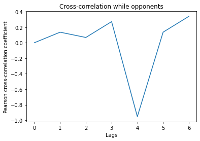

```python
plt.plot(crossCorr_before)
plt.xlabel('Lags')
plt.ylabel('Pearson cross-correlation coefficient')
plt.title('Cross-correlation while opponents')
```

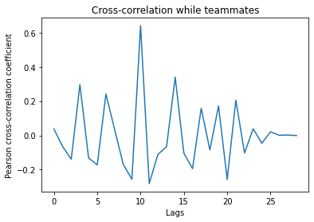

```python
plt.plot(crossCorr_after)
plt.xlabel('Lags')
plt.ylabel('Pearson cross-correlation coefficient')
plt.title('Cross-correlation while teammates')
```

```python
print(f'Correlation before becoming teammates: {min(crossCorr_before)}')
```

```
Correlation before becoming teammates: -0.9525793444156805
```

```python
print(f'Correlation after becoming teammates: {max(crossCorr_after)}')
```

```
Correlation after becoming teammates: 0.6399461533465507
```

This shows there is some apparent change in correlation, though data is rather sparse.